# Getting to know your incomplete data

## Preface

### R packages

In this practical, a number of R packages are used. If any of them are not installed you can still follow the practical but will not be able to run all of the code. The packages used (with versions that were used to generate the solutions) are:

- `mice` (version: 3.3.0)
- `visdat` (version: 0.5.2)
- `JointAI` (version: 0.4.0.9000)
- `VIM` (version: 4.7.0)
- `plyr` (version: 1.8.4)

### Help files

You can find help files for any function by adding a `?` before the name of the function.

Alternatively, you can look up the help pages online at https://www.rdocumentation.org/ or find the whole manual for a package at https://cran.r-project.org/web/packages/available_packages_by_name.html

## Dataset

### Overview

For this example, we will use the **NHANES** dataset. To load this dataset, you can use the command `file.choose()` which opens the explorer and allows you to navigate to the location of the file `NHANES_for_practicals.RData` on your computer. If you know the path to the file, you can also use `load("<path>/NHANES_for_practicals.RData")`.

#### Task

Let’s take a first look at the data. Useful functions are `dim()`, `head()`, `str()` and `summary()`.

#### Solution

```r
dim(NHANES)
```

```
## [1] 1000   26
```

```r
head(NHANES)
```

|  | occup | BMI | HDL | DM | hypchol | NowHyperMed | hgt | SBP | hypten | DBP | cohort | age | WC | EverHyperMed | chol | creat | gender | wgt | bili | smoke | albu | educ | race | uricacid | alc | HyperMed |
| --- | --- | --- | --- | --- | --- | --- | --- | --- | --- | --- | --- | --- | --- | --- | --- | --- | --- | --- | --- | --- | --- | --- | --- | --- | --- | --- |
| 848 | working | 29.49730 | 1.01 | yes | yes | yes | 1.7272 | 152.6667 | yes | 90.66667 | 2011 | 63 | 107.4 | yes | 6.54 | 0.72 | male | 87.99692 | 0.7 | never | 4.1 | High school graduate | Other Hispanic | 4.7 | NA | yes |
| 587 | working | 26.49935 | NA | no | NA | NA | 1.8034 | NaN | NA | NaN | 2011 | 53 | 96.2 | NA | NA | NA | male | 86.18255 | NA | never | NA | College or above | Non-Hispanic Black | NA | NA | NA |
| 2710 | working | 20.67417 | 1.60 | no | no | NA | 1.7526 | 130.6667 | no | 68.00000 | 2011 | 42 | 74.5 | NA | 4.19 | 0.71 | female | 63.50293 | 0.6 | current | 4.1 | some college | Non-Hispanic White | 5.1 | 3-7 | NA |
| 2358 | not working | 23.32715 | 1.01 | yes | no | NA | 1.8288 | 148.0000 | yes | 66.00000 | 2011 | 77 | 105.1 | NA | 2.17 | 0.79 | male | 78.01789 | 1.2 | former | 4.6 | 9-11th grade | Non-Hispanic White | 5.1 | <=1 | NA |
| 599 | working | 25.38359 | 1.16 | no | no | NA | 1.8034 | 114.6667 | yes | 63.33333 | 2011 | 31 | 95.6 | no | 4.73 | 1.43 | male | 82.55381 | 0.5 | never | 4.3 | College or above | Non-Hispanic White | 5.2 | >7 | no |
| 762 | working | 24.44535 | 1.45 | no | no | NA | 1.6002 | 107.3333 | no | 68.66667 | 2011 | 46 | 96.0 | NA | 5.74 | 0.66 | female | 62.59575 | 0.8 | current | 4.0 | High school graduate | Non-Hispanic White | 4.3 | >7 | NA |

```r
str(NHANES)
```

```
## 'data.frame':    1000 obs. of  26 variables:
##  $ occup       : Factor w/ 3 levels "working","looking for work",..: 1 1 1 3 1 1 2 1 1 3 ...
##  $ BMI         : num  29.5 26.5 20.7 23.3 25.4 ...
##  $ HDL         : num  1.01 NA 1.6 1.01 1.16 1.45 1.01 1.32 1.84 0.91 ...
##  $ DM          : Factor w/ 2 levels "no","yes": 2 1 1 2 1 1 1 1 1 2 ...
##  $ hypchol     : Factor w/ 2 levels "no","yes": 2 NA 1 1 1 1 1 1 1 1 ...
##  $ NowHyperMed : Factor w/ 2 levels "yes","no": 1 NA NA NA NA NA NA NA 1 1 ...
##  $ hgt         : num  1.73 1.8 1.75 1.83 1.8 ...
##  $ SBP         : num  153 NaN 131 148 115 ...
##  $ hypten      : Factor w/ 2 levels "no","yes": 2 NA 1 2 2 1 1 1 2 2 ...
##  $ DBP         : num  90.7 NaN 68 66 63.3 ...
##  $ cohort      : chr  "2011" "2011" "2011" "2011" ...
##  $ age         : num  63 53 42 77 31 46 46 43 44 75 ...
##  $ WC          : num  107.4 96.2 74.5 105.1 95.6 ...
##  $ EverHyperMed: Factor w/ 2 levels "yes","no": 1 NA NA NA 2 NA NA NA 1 1 ...
##  $ chol        : num  6.54 NA 4.19 2.17 4.73 5.74 5.92 4.58 5.33 4.78 ...
##  $ creat       : num  0.72 NA 0.71 0.79 1.43 0.66 1.02 1.12 0.75 1.02 ...
##  $ gender      : Factor w/ 2 levels "male","female": 1 1 2 1 1 2 1 1 2 1 ...
##  $ wgt         : num  88 86.2 63.5 78 82.6 ...
##  $ bili        : num  0.7 NA 0.6 1.2 0.5 0.8 0.8 0.8 0.6 0.8 ...
##  $ smoke       : Ord.factor w/ 3 levels "never"<"former"<..: 1 1 3 2 1 3 1 3 3 2 ...
##  $ albu        : num  4.1 NA 4.1 4.6 4.3 4 4.2 3.9 4.1 4 ...
##  $ educ        : Factor w/ 5 levels "Less than 9th grade",..: 3 5 4 2 5 3 3 1 3 4 ...
##  $ race        : Factor w/ 5 levels "Mexican American",..: 2 4 3 3 3 3 4 1 4 3 ...
##  $ uricacid    : num  4.7 NA 5.1 5.1 5.2 4.3 6.3 5.4 4.2 6.7 ...
##  $ alc         : Ord.factor w/ 5 levels "0"<"<=1"<"1-3"<..: NA NA 4 2 5 5 2 5 4 NA ...
##  $ HyperMed    : Ord.factor w/ 3 levels "no"<"previous"<..: 3 NA NA NA 1 NA NA NA 3 3 ...
```

```r
summary(NHANES)
```

```
##               occup          BMI                HDL          DM      hypchol    NowHyperMed
##  working         :537   Min.   :   0.001   Min.   :0.360   no :842   no  :816   yes :213
##  looking for work: 54   1st Qu.:  23.013   1st Qu.:1.110   yes:158   yes : 99   no  : 30
##  not working     :392   Median :  26.608   Median :1.320             NA's: 85   NA's:757
##  NA's            : 17   Mean   :  35.753   Mean   :1.374
##                         3rd Qu.:  31.173   3rd Qu.:1.580
##                         Max.   :1828.822   Max.   :3.570
##                         NA's   :9          NA's   :85
##       hgt               SBP          hypten         DBP            cohort               age
##  Min.   :  1.422   Min.   : 81.33   no  :615   Min.   :  0.00   Length:1000        Min.   :20.00
##  1st Qu.:  1.600   1st Qu.:109.33   yes :353   1st Qu.: 64.00   Class :character   1st Qu.:31.00
##  Median :  1.676   Median :118.67   NA's: 32   Median : 70.67   Mode  :character   Median :44.00
##  Mean   :  4.722   Mean   :121.28              Mean   : 70.76                      Mean   :45.55
##  3rd Qu.:  1.753   3rd Qu.:130.67              3rd Qu.: 78.00                      3rd Qu.:59.00
##  Max.   :253.975   Max.   :222.00              Max.   :110.00                      Max.   :79.00
##  NA's   :3         NA's   :48                  NA's   :48
##        WC         EverHyperMed      chol            creat          gender         wgt
##  Min.   : 65.50   yes :244     Min.   : 2.070   Min.   :0.340   male  :488   Min.   :  38.55
##  1st Qu.: 84.47   no  : 54     1st Qu.: 4.270   1st Qu.:0.695   female:512   1st Qu.:  63.50
##  Median : 95.60   NA's:702     Median : 4.910   Median :0.820                Median :  77.11
##  Mean   : 96.97                Mean   : 4.974   Mean   :0.866                Mean   : 123.38
##  3rd Qu.:106.12                3rd Qu.: 5.590   3rd Qu.:0.970                3rd Qu.:  90.72
##  Max.   :176.00                Max.   :10.290   Max.   :6.290                Max.   :4535.47
##  NA's   :56                    NA's   :85       NA's   :89                   NA's   :6
##       bili            smoke          albu                         educ                     race
##  Min.   :0.2000   never  :564   Min.   :2.900   Less than 9th grade : 81   Mexican American  :107
##  1st Qu.:0.6000   former :198   1st Qu.:4.100   9-11th grade        :143   Other Hispanic    :112
##  Median :0.7000   current:236   Median :4.300   High school graduate:211   Non-Hispanic White:368
##  Mean   :0.7299   NA's   :  2   Mean   :4.267   some college        :302   Non-Hispanic Black:221
##  3rd Qu.:0.9000                 3rd Qu.:4.500   College or above    :262   other             :192
##  Max.   :2.7000                 Max.   :5.200   NA's                :  1
##  NA's   :90                     NA's   :89
##     uricacid        alc          HyperMed
##  Min.   : 1.800   0   :144   no      : 54
##  1st Qu.: 4.400   <=1 :274   previous: 30
##  Median : 5.300   1-3 : 96   yes     :213
##  Mean   : 5.406   3-7 : 85   NA's    :703
##  3rd Qu.: 6.300   >7  :127
##  Max.   :11.300   NA's:274
##  NA's   :90
```

### Variable coding

It is important to check that all variables are coded correctly, i.e., have the correct `class`. Imputation software (e.g., the **mice** package) uses the `class` to automatically select imputation methods. When importing data from other software it can happen that factors become continuous variables or that ordered factors lose their ordering.

`str()` showed that in the NHANES data `smoke` and `alc` are correctly specified as ordinal variables, but `educ` is an unordered factor.

#### Task

Using `levels(NHANES$educ)` we can print the names of the categories of `educ`. Convert the unordered factor to an ordered factor, for example using `as.ordered()`. Afterwards, check if the conversion was successful.

#### Solution

```r
levels(NHANES$educ)
```

```
## [1] "Less than 9th grade"  "9-11th grade"         "High school graduate" "some college"
## [5] "College or above"
```

```r
NHANES$educ <- as.ordered(NHANES$educ)

str(NHANES$educ)
```

```
##  Ord.factor w/ 5 levels "Less than 9th grade"<..: 3 5 4 2 5 3 3 1 3 4 ...
```

## Distribution of missing values

### Missing data pattern

In the `summary()` we could already see that there are missing values in several variables. The missing data pattern can be obtained and visualized by several functions from different packages. Examples are

- `md.pattern()` from package **mice**
- `md_pattern()` from package **JointAI** (with argument `patter = TRUE`)
- `aggr()` from package **VIM**
- `vis_dat()` and `vis_miss()` from package **visdat**

#### Task

Explore the missing data pattern of the NHANES data.

#### Solution (i)

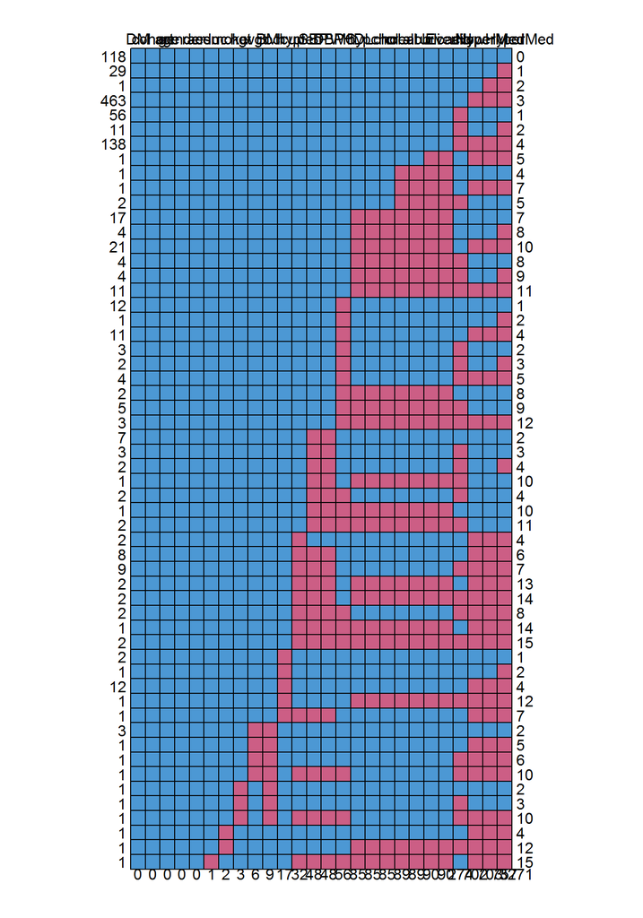

```r
mdp <- mice::md.pattern(NHANES)
```

```r
mdp
```

```
##     DM cohort age gender race educ smoke hgt wgt BMI occup hypten SBP DBP WC HDL hypchol chol creat
## 118  1      1   1      1    1    1     1   1   1   1     1      1   1   1  1   1       1    1     1
## 29   1      1   1      1    1    1     1   1   1   1     1      1   1   1  1   1       1    1     1
## 1    1      1   1      1    1    1     1   1   1   1     1      1   1   1  1   1       1    1     1
## 463  1      1   1      1    1    1     1   1   1   1     1      1   1   1  1   1       1    1     1
## 56   1      1   1      1    1    1     1   1   1   1     1      1   1   1  1   1       1    1     1
## 11   1      1   1      1    1    1     1   1   1   1     1      1   1   1  1   1       1    1     1
## 138  1      1   1      1    1    1     1   1   1   1     1      1   1   1  1   1       1    1     1
## 1    1      1   1      1    1    1     1   1   1   1     1      1   1   1  1   1       1    1     1
## 1    1      1   1      1    1    1     1   1   1   1     1      1   1   1  1   1       1    1     0
## 1    1      1   1      1    1    1     1   1   1   1     1      1   1   1  1   1       1    1     0
## 2    1      1   1      1    1    1     1   1   1   1     1      1   1   1  1   1       1    1     0
## 17   1      1   1      1    1    1     1   1   1   1     1      1   1   1  1   0       0    0     0
## 4    1      1   1      1    1    1     1   1   1   1     1      1   1   1  1   0       0    0     0
## 21   1      1   1      1    1    1     1   1   1   1     1      1   1   1  1   0       0    0     0
```

[output cut: 101 more lines]

`md.pattern()` from package **mice** gives us a matrix where each row represents one missing data pattern (1 = observed, 0 = missing). The rownames show how many rows of the dataset have the given pattern. The last column shows the number of missing values in each pattern, the last row the number of missing values per variable.

`md.pattern()` also plots the missing data pattern automatically.

#### Solution (ii)

```r
MDP <- JointAI::md_pattern(NHANES, pattern = TRUE)
```

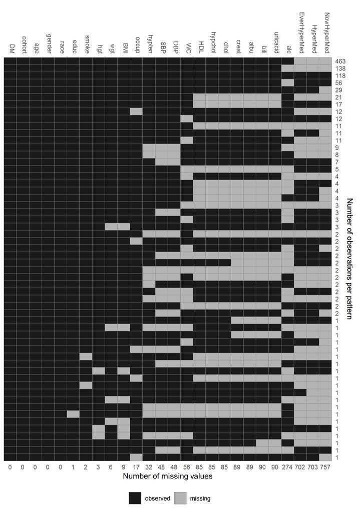

```r
MDP
```

```
##      DM cohort age gender race educ smoke hgt wgt BMI occup hypten SBP DBP WC HDL hypchol chol
## 1     1      1   1      1    1    1     1   1   1   1     1      1   1   1  1   1       1    1
## 2     1      1   1      1    1    1     1   1   1   1     1      1   1   1  1   1       1    1
## 3     1      1   1      1    1    1     1   1   1   1     1      1   1   1  1   1       1    1
## 4     1      1   1      1    1    1     1   1   1   1     1      1   1   1  1   1       1    1
## 5     1      1   1      1    1    1     1   1   1   1     1      1   1   1  1   1       1    1
## 6     1      1   1      1    1    1     1   1   1   1     1      1   1   1  1   0       0    0
## 7     1      1   1      1    1    1     1   1   1   1     1      1   1   1  1   0       0    0
## 8     1      1   1      1    1    1     1   1   1   1     0      1   1   1  1   1       1    1
## 9     1      1   1      1    1    1     1   1   1   1     1      1   1   1  0   1       1    1
## 10    1      1   1      1    1    1     1   1   1   1     1      1   1   1  1   0       0    0
## 11    1      1   1      1    1    1     1   1   1   1     1      1   1   1  1   1       1    1
## 12    1      1   1      1    1    1     1   1   1   1     1      1   1   1  0   1       1    1
## 13    1      1   1      1    1    1     1   1   1   1     1      0   0   0  1   1       1    1
## 14    1      1   1      1    1    1     1   1   1   1     1      0   0   0  1   1       1    1
```

[output cut: 101 more lines]

The function `md_pattern()` from package **JointAI** gives a matrix very similar to the one obtained from `mice::md.pattern()`. Hovever, here, the number of rows in the data that have a particular missing data pattern are given in the last column.

For more information on how to customize the visualization by `md_pattern()` see the vignette [Visualizing Incomplete Data](https://nerler.github.io/JointAI/articles/VisualizingIncompleteData.html) on the [webpage of **JointAI**](https://nerler.github.io/JointAI/index.html).

#### Solution (iii)

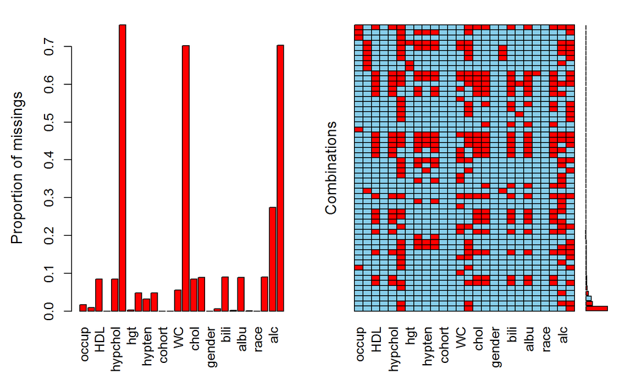

```r
VIM::aggr(NHANES)
```

`aggr()` from **VIM** plots a histogram of the proportion of missing values per column as well as a visualization of the missing data pattern. Here, a small histogram on the right edge of the plot shows the proportion of cases in each pattern.

For more options how to customize the plot, see the [**VIM** documentation](https://CRAN.R-project.org/package=VIM).

### Proportion of missing values

#### Task

Now get an overview of

- how much missingness there is in each variable, and
- the proportion of (in)complete cases.

The function `complete.cases()` will give you a vector that is TRUE if the the case is complete and FALSE if there are missing values.

`is.na()` returns `TRUE` if the value is missing, `FALSE` if the value is observed

`colSums()` calculates the sum of values in each column of a data.frame or matrix

`colMeans()` calculates the mean of values in each column of a data.frame or matrix

#### Solution

```r
# number and proportion of complete cases
cbind(
  "#" = table(ifelse(complete.cases(NHANES), 'complete', 'incomplete')),
  "%" = round(100 * table(complete.cases(NHANES))/nrow(NHANES), 2)
)
```

```
##              #    %
## complete   118 88.2
## incomplete 882 11.8
```

```r
# number and proportion of missing values per variable
cbind("# NA" = sort(colSums(is.na(NHANES))),
      "% NA" = round(sort(colMeans(is.na(NHANES))) * 100, 2))
```

```
##              # NA % NA
## DM              0  0.0
## cohort          0  0.0
## age             0  0.0
## gender          0  0.0
## race            0  0.0
## educ            1  0.1
## smoke           2  0.2
## hgt             3  0.3
## wgt             6  0.6
## BMI             9  0.9
## occup          17  1.7
## hypten         32  3.2
## SBP            48  4.8
## DBP            48  4.8
## WC             56  5.6
## HDL            85  8.5
## hypchol        85  8.5
## chol           85  8.5
## creat          89  8.9
## albu           89  8.9
## bili           90  9.0
## uricacid       90  9.0
## alc           274 27.4
## EverHyperMed  702 70.2
## HyperMed      703 70.3
## NowHyperMed   757 75.7
```

### Relationship between variables

In the missing data pattern we could already see that some variables tend to be missing together. But there may be different types of relationships between variables that are of interest.

#### Task 1

Our data contains `hgt` (height), `wgt` (weight) and `BMI`. Check the missing data pattern specifically for those three variables.

#### Solution 1

```r
# Three solutions to choose from:
JointAI::md_pattern(NHANES[, c("hgt", "wgt", "BMI")], pattern = TRUE, plot = FALSE)
```

```
##      hgt wgt BMI Npat
## 1      1   1   1  991
## 2      1   0   0    6
## 3      0   1   0    3
## Nmis   3   6   9   18
```

```r
with(NHANES,
     table(ifelse(is.na(hgt), 'height mis.', 'height obs.'),
           ifelse(is.na(wgt), 'weight mis.', 'weight obs.'),
           ifelse(is.na(BMI), 'BMI mis.', 'BMI obs.'))
)
```

```
## , ,  = BMI mis.
##
##
##               weight mis. weight obs.
##   height mis.           0           3
##   height obs.           6           0
##
## , ,  = BMI obs.
##
##
##               weight mis. weight obs.
##   height mis.           0           0
##   height obs.           0         991
```

```r
plyr::ddply(NHANES, c(height = "ifelse(is.na(hgt), 'missing', 'observed')",
                      weight = "ifelse(is.na(wgt), 'missing', 'observed')",
                      BMI = "ifelse(is.na(BMI), 'missing', 'observed')"),
            plyr::summarize,
            N = length(hgt)
)
```

| height | weight | BMI | N |
| --- | --- | --- | --- |
| missing | observed | missing | 3 |
| observed | missing | missing | 6 |
| observed | observed | observed | 991 |

As we have already seen in the lecture, there are some cases where only either `hgt` or `wgt` is missing. `BMI` is only observed when both components are observed. To use all available information, we want to impute `hgt` and `wgt` separately and calculate `BMI` from the imputed values.

#### Task 2

The data contains variables on hypertension (`hypten`) and the use of medication to treat hypertension (`HyperMed`). We might expect that medication is only prescribed for patients with hypertension, hence, we need to investigate the relationship between `HyperMed` and `hypten`.

- Make a table of the two variables to confirm our expectation.
- Make sure that missing values are also displayed in that table!

#### Solution 2

```r
with(NHANES, table(HyperMed, hypten, exclude = NULL))
```

```
##           hypten
## HyperMed    no yes <NA>
##   no         0  54    0
##   previous   0  30    0
##   yes        0 213    0
##   <NA>     615  56   32
```

#### Task 3

Furthermore, we can expect a systematic relationship between the variables `hypchol` (Hypercholesterolemia) and `chol` (serum cholesterol). Find out how these two variables are related.

#### Solution 3

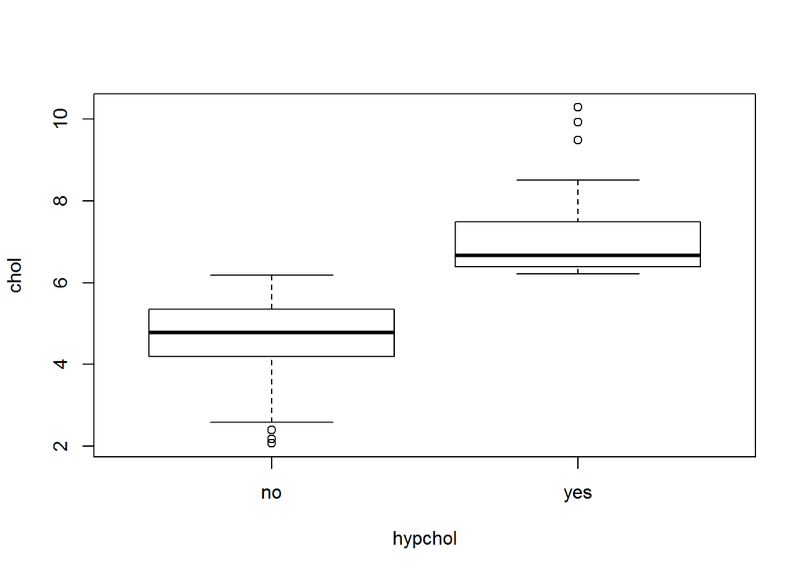

```r
with(NHANES, plot(chol ~ hypchol))
```

```r
with(NHANES, summary(chol[hypchol == "no"]))
```

```
##    Min. 1st Qu.  Median    Mean 3rd Qu.    Max.    NA's
##    2.07    4.19    4.78    4.73    5.35    6.18      85
```

```r
with(NHANES, summary(chol[hypchol == "yes"]))
```

```
##    Min. 1st Qu.  Median    Mean 3rd Qu.    Max.    NA's
##   6.210   6.390   6.670   6.991   7.485  10.290      85
```

It seems that `hypchol` is defined as `chol > 6.2`, which makes `hypchol` dependent on `chol`.

## Distribution of the data

Before imputing missing values it is important to take a look at how the observed parts of incomplete variables are distributed, so that we can choose appropriate imputation models.

### Task

Visualize the distributions of the incomplete continuous and categorical variables. The package **JointAI** provides the convenient function `plot_all()`,

Pay attention to

- whether continuous distributions deviate considerably from the normal distribution,
- if variables have values close to the limits of the range they are defined in,
- whether categorical variables are very unbalanced (i.e., some category very small).

### Solution

```r
par(mar = c(3, 3, 2, 1), mgp = c(2, 0.6, 0))
JointAI::plot_all(NHANES, nclass = 30, ncol = 4)
```

[figure not shown]

To learn more about additional options of `plot_all()` check out the vignette [Visualizing Incomplete Data](https://nerler.github.io/JointAI/articles/VisualizingIncompleteData.html) on the [webpage of **JointAI**](https://nerler.github.io/JointAI/index.html).